# Lesson 103 — TGAT: attention that knows when

Executed teacher solution; PENDING_WRITTEN_DEFENSE is the learner status.

[HTML lesson](https://avistian.github.io/relational/lessons/0103-tgat.html). Figures are embedded; model and trainer code are fully visible.

```python
# @colab-bootstrap — standalone visible implementation; no course package needed.
import sys
print('Python',sys.version.split()[0])
# If imports below are missing: %pip install torch numpy pandas scikit-learn
```

```
Python 3.12.3
```

## Runtime and data

Tier B: real Wikipedia interaction graph. First use downloads a 534 MiB hash-checked raw file. Allow about 2 GiB RAM for parsing. The default run uses a declared 600/120/120 event slice, one epoch, both models. It is not the historical experiment. The full released two-layer TGAT uses the complete dataset and ten seeds. GPU runtime pins: torch 2.8.0, numpy 2.2.6, pandas 2.3.2, scikit-learn 1.7.1; CPU author runtime is recorded in the evidence. Live Colab is NOT_CHECKED. After this lesson is published the course URLs work; local source files are supplied with the package.

From Lesson 102 to this lesson

TGN kept a running node memory. TGAT instead rebuilds a representation from retrieved events; the new question is how elapsed time changes attention.

**Quick prerequisite reminder**

An embedding is a vector representing an entity. Attention forms a weighted sum of neighbor vectors. A cutoff is the time beyond which a query cannot read records.

**Your tangible win:** implement a continuous-time attention layer and trace exactly which events can influence its prediction. The lab then connects that implementation to a complete released Wikipedia experiment.

Read the core lesson in one sitting; do the lab and reproduction audit separately. Running the teacher's solution does not demonstrate mastery. Your status remains **PENDING_WRITTEN_DEFENSE** until you submit the written defense.

## 1 · From TGN's stored memory to TGAT's retrieved history

In [lesson 102](https://avistian.github.io/relational/lessons/0102-temporal-graph-networks.html), TGN compressed observed interactions into a persistent vector for each node. A message updated that vector through a recurrent unit. The vector carried history into later predictions.

TGAT takes another route. For a request “represent user A at time 8,” it retrieves earlier interactions and computes an embedding from them. An **embedding** is a vector used to score a candidate pair or classify a node. TGAT does not maintain a learned recurrent state for every node between requests. It still needs the timestamped event store; “memoryless” does not mean “no history” or “no storage.”

> **In plain terms.** TGN keeps a running summary. TGAT revisits selected records whenever it needs an answer. Both must establish what was available before the prediction.

This distinction matters for relational learning. A customer query may need recent orders, repeated visits, and older but relevant purchases. A static neighborhood tells us who interacted; a temporal neighborhood also tells us **when**. [Xu et al., §§1–3](https://arxiv.org/html/2002.07962v1#S3) develops a way to put elapsed time inside the attention computation.

The tradeoff is concrete. Persistent memory can summarize a long stream, but its state must be restored and updated correctly. Recursive retrieval avoids that recurrent state, but adds repeated neighborhood computation. Neither property alone establishes which model will predict better. With 20 neighbors and two layers, the neighbor branch can request 400 second-hop records per endpoint before accounting for repeated requests. Reusing an embedding by node ID alone is unsafe: the same node queried at different times may have different legal histories.

## 2 · First make the neighborhood causal

An event is a tuple **(u, v, t, e)**: source node, destination node, timestamp, and event features. A temporal graph can contain many interactions between the same pair. These are separate records, not one edge with an updated label.

For a query **(u, t)**, the intended neighborhood contains events incident to u with event time **tᵢ < t**. Equal timestamps are excluded by this convention. This dataset protocol assumes the event is available at its timestamp; as lesson 101 showed, a real system must also check arrival or availability time. If your application knows an order within equal timestamps, that requires an explicit alternative protocol.

**Worked example.** A interacted with B at time 1, C at time 3, and D at time 5. At query time 4, the correct history is B@1 and C@3. D@5 is unavailable. A sorted-array lower-bound search gives the first index whose time is at least 4; every earlier index is eligible.

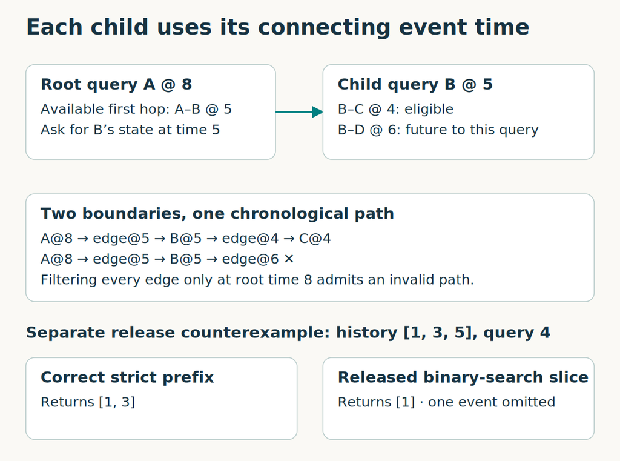

A child reached through an event at time 5 must use history before 5, even when the root query is at time 8. The lower panel separately shows a released sampler defect.

**A second layer changes the cutoff.** Suppose A's query at 8 retrieves B through their interaction at 5. B's representation must be evaluated at **5**, not at 8. An event B–C at 6 is already in the past of the root query, but still in the future of B's historical representation. This is why an outer time filter is insufficient. See [§3.2 and §3.4](https://arxiv.org/html/2002.07962v1#S3.S2).

**Predict before checking:** is B–C@4 legal? Is B–C@5 legal? Explain the boundary before opening the answer.

**Check the recursive path**

Time 4 is legal; time 5 is excluded by the strict boundary. Each recursive request carries its own cutoff. The path's timestamps decrease as you move backward through the retrieved history.

> **Scope check.** The released neighbor search has an off-by-one prefix bug: on history [1, 3, 5] at cutoff 4 it returns only [1]. Our published-experiment replay preserves this behavior to audit the release. The corrected comparison and your strict-boundary task return [1, 3]. These are separate experiments, not interchangeable fixes.

## 3 · Represent elapsed time with learnable waves

A timestamp is a number; attention expects feature vectors. Simply appending a huge timestamp can make its numerical scale dominate other features. What often matters is the **elapsed time**, Δt = query time − event time. For real-event inputs, using elapsed time also makes a joint shift of query and event timestamps leave that input unchanged.

### 3.1 · Why sine and cosine appear

**First-pass intuition.** Different frequencies provide clocks that cycle at different speeds. Their coordinates give attention a way to compare elapsed times. Work the one-frequency example below first; the theorem explains why the paired construction has a useful symmetry. You can return to that proof after tracing the model.

A **kernel** is a function measuring similarity between two inputs. A **stationary**, or translation-invariant, temporal kernel depends on their difference, not the origin of the clock. A **positive semidefinite** kernel has a Gram matrix K for which aᵀKa ≥ 0 for every vector a. This makes it compatible with representing similarity as an inner product.

Bochner's theorem connects continuous stationary positive semidefinite kernels to nonnegative spectral measures. For a normalized real temporal kernel, the paper expresses similarity as an average of cos(ω(t₁−t₂)). Here **ω** is an angular frequency: it controls how quickly a wave varies with time. A normalized measure can be viewed as a frequency distribution. [Paper §3.1, Eqs. 3–5](https://arxiv.org/html/2002.07962v1#S3.S1).

The useful identity is:

**cos(a−b) = cos(a)cos(b) + sin(a)sin(b).**

For m frequencies, define φ(t) = [cos(ω₁t), sin(ω₁t), …, cos(ωₘt), sin(ωₘt)] / √m. This vector has **2m coordinates**. Its inner product at t₁ and t₂ is the average of cos(ωⱼ(t₁−t₂)). Paired sine and cosine cancel the dependence on the common clock origin. The paper's dimension notation is loose; count the coordinates explicitly in code.

**Worked example.** With one frequency ω=1, φ(0)=[1,0] and φ(π/2)=[0,1]. Their inner product is zero. Shift both times by π/2: the vectors become [0,1] and [−1,0], whose inner product is still zero.

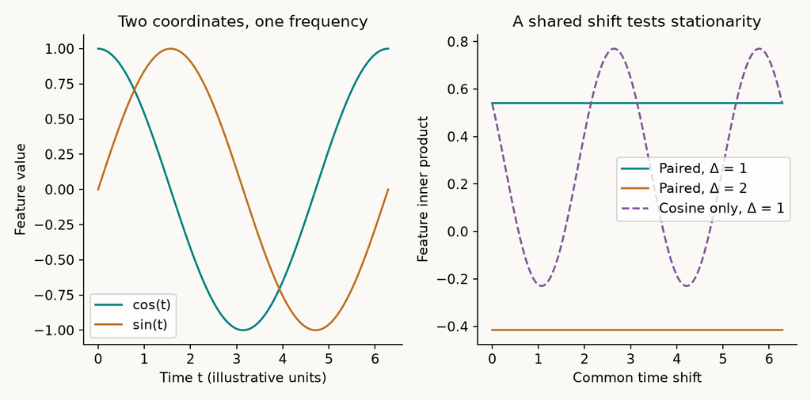

Illustrative fixed frequencies: paired sine/cosine inner products preserve time differences. A cosine-only inner product can change under a common shift of its arguments.

The theorem motivates the representation. It does not say that every trained attention layer is a stationary kernel, or that finite learned frequencies prove the paper's Monte Carlo approximation guarantee. The guarantee assumes frequencies sampled from a specified spectral distribution. The network instead optimizes frequency parameters jointly with its task loss.

### 3.2 · What the released code actually trains

The released `TimeEncode` uses **cos(ωⱼ Δt + bⱼ)**, with learned frequencies and phases. Its 172 initial frequencies range geometrically from 1 to 10⁻⁹; initial phases are zero. It does not explicitly stack the paired sine/cosine vector or divide by √m. See the [released encoder](https://github.com/StatsDLMathsRecomSys/Inductive-representation-learning-on-temporal-graphs/blob/9293d10d1943c4bd4a186337cf38ba98e4c8bb99/module.py).

A cosine-only inner product need not be stationary in its two arguments: cos(a)cos(b) includes a term depending on a+b. Do not transfer the paired-feature identity to this finite released representation. For **real events**, a joint shift of query and event timestamps leaves elapsed times unchanged. That establishes a property of the relative-time inputs, not automatically of the complete released model. Its fixed time-zero padding can break full-model invariance when an empty history receives uniform attention; section 4 demonstrates this distinction.

**Time units matter.** Changing seconds to days changes the inputs by a factor of 86400. Equivalent waves require corresponding inverse rescaling of frequencies. The replay keeps the released timestamp units without normalization.

## 4 · Model architecture: time becomes part of the attention decision

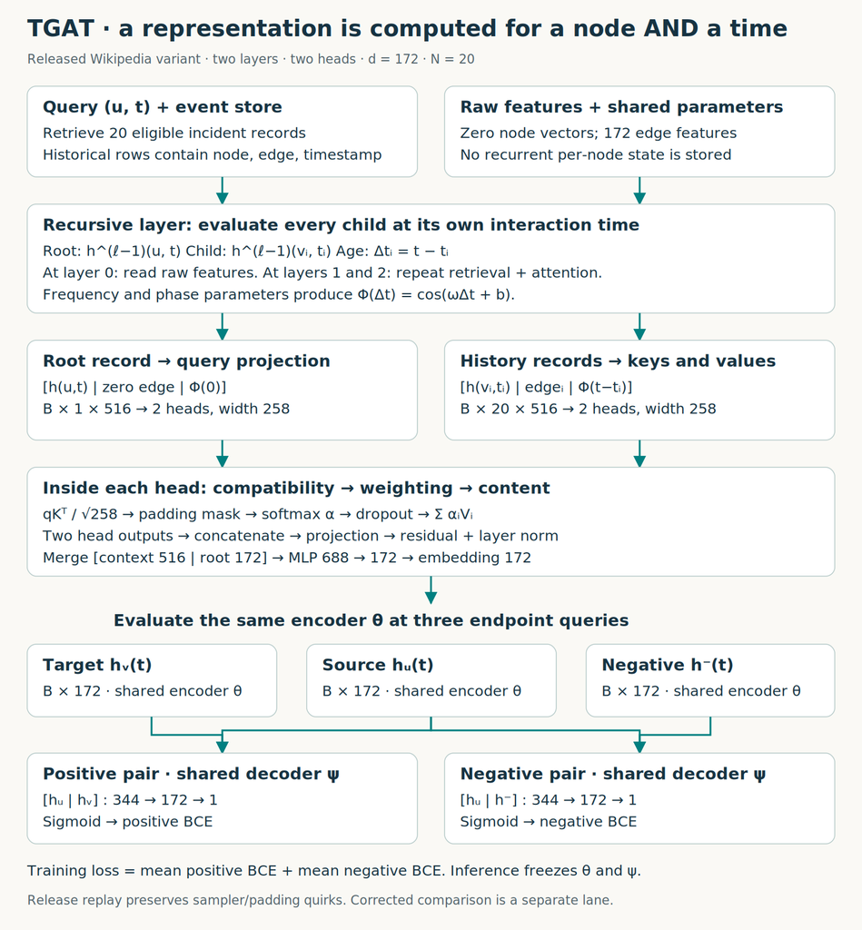

Trace each endpoint from its timestamped query through two recursive layers to the shared pair decoder. Shapes describe the released Wikipedia variant.

**Diagram trace.** Follow one source–target pair. Where does the child cutoff change, and which encoder weights are shared with the negative pair? On a narrow screen, scroll the figure sideways.

The diagram shows the released two-layer Wikipedia variant. **B** is batch size, **N=20** is sampled neighbors per request, and **d=172** is node, edge, and time width. Each layer has two heads. A **head** is a separately learned query/key/value projection and weighted aggregation.

**Attention vocabulary.** A query vector describes what the root is looking for. A key vector describes a candidate neighbor for comparison. A value vector supplies the content to be combined after those comparisons become weights. These are learned projections, not database keys.

### Step 1 · Recursively construct the input records

The base representation h⁰ᵤ(t) is the node's raw feature vector. Wikipedia's released node vectors are zero; interaction edge features carry information. At layer ℓ, compute the root's h^(ℓ−1)ᵤ(t), retrieve incident records, and compute each neighbor h^(ℓ−1)ᵢ(tᵢ). The same lower-layer parameters are shared across those requests. This is the inductive contract: an unseen node can be processed using the same learned function when its features and legal history are supplied. It is not a guarantee of accurate cold-start predictions; zero-feature nodes with no history carry little distinguishing information. [Paper §3.2](https://arxiv.org/html/2002.07962v1#S3.S2).

**Follow the implementation.** The recursive method below is the code used by the experiment. Notice which timestamp becomes the child cutoff, and where the student-written encoder and attention functions enter through the layer modules.

```
    def tem_conv(self,nodes,cutoffs,layer,num_neighbors=20):
        device=self.n_feat_th.device
        raw=self.node_raw_embed(torch.as_tensor(nodes,dtype=torch.long,device=device))
        if layer==0:return raw
        source=self.tem_conv(nodes,cutoffs,layer-1,num_neighbors)
        nbr,eid,when=self.ngh_finder.get_temporal_neighbor(nodes,cutoffs,num_neighbors)
        child=self.tem_conv(nbr.ravel(),when.ravel(),layer-1,num_neighbors).reshape(len(nodes),num_neighbors,-1)
        elapsed=torch.as_tensor(cutoffs[:,None]-when,dtype=torch.float32,device=device)
        time_features=self.time_encoder(elapsed)
        zero_time=self.time_encoder(torch.zeros((len(nodes),1),device=device))
        edge=self.edge_raw_embed(torch.as_tensor(eid,dtype=torch.long,device=device))
        padding=torch.as_tensor(nbr==0,device=device)
        return self.attn_model_list[layer-1](source,zero_time,child,time_features,edge,padding)
```

### Step 2 · Assemble a query and candidate records

The root record is **[root embedding, zero edge vector, Φ(0)]**, shape B×1×516. A neighbor record is **[neighbor embedding at tᵢ, edge features, Φ(t−tᵢ)]**, shape B×20×516. Concatenation preserves all three sources of information. The current candidate interaction's features are not inserted into its own query history.

The projections produce q, K and V. For each head their final dimension is 516/2 = **258**. The **query** describes what the root seeks; the **keys** determine compatibility; the **values** carry the information that will be combined. Time can affect both compatibility and content because it enters both K and V.

### Step 3 · Normalize compatibility over available records

For neighbor i, compute scoreᵢ = q·kᵢ/√258. The divisor keeps dot-product scale from growing with head width. Softmax converts scores to nonnegative attention weights that sum to one before dropout. Padding positions are masked. Attention dropout during training means the realized post-dropout weights need not sum to one.

Then context = Σᵢ αᵢvᵢ. The two head outputs are concatenated and projected. The release adds the root query as a residual connection and applies layer normalization. A feed-forward merge concatenates the 516-dimensional context with the root's 172-dimensional previous-layer representation. Its widths are **688 → 172 → 172**, yielding the next node embedding.

> **Scope check.** The finite −10¹⁰ release mask gives an all-padding row uniform weights. Values can contain nonzero time encodings even when raw node and edge vectors are zero. Thus “no neighbors” is not generally equivalent to “zero context.” Our source parity tests include padding; the lesson does not silently substitute another convention.

**Source-confirmed counterexample.** In a synthetic, untrained two-layer model with no history, shift a query from time 2 to time 12. Padded event times remain zero, so the artificial ages change from 2 to 12. Keeping every weight fixed gives:

| Attention convention | Probability at t=2 | Probability at t=12 |
| --- | --- | --- |
| Released finite mask | 0.597007 | 0.595062 |
| Zero all-padding weights, same parameters | 0.597401 | 0.597401 |

These are diagnostic probabilities, not Wikipedia AP or trained evidence. The original model and the port agree exactly on the released case. The zero-safe intervention isolates the padding mechanism; it is **not** applied to the published-experiment replay. [Executable counterexample](https://avistian.github.io/relational/labs/_padding_check_l103.py) · [Measured diagnostic](https://avistian.github.io/relational/labs/_padding_check_l103_results.json).

### Step 4 · Predict a pair using shared embeddings

Compute hᵤ(t) and hᵥ(t) with the same TGAT encoder. Concatenate them and pass them through the shared pair MLP: 344 → 172 → 1. A sigmoid maps the logit to a probability. During training, also encode a sampled negative destination and use the same decoder. The loss is mean positive binary cross-entropy plus mean negative binary cross-entropy.

A negative destination is a contrastive example, not proof that the pair can never interact. Release sampling allows collisions with positive pairs. These choices affect the task and the interpretation of AP. The released evaluation uses the full dataset's endpoint universe as a candidate pool. That is a benchmark convention, not evidence that every candidate identity was already known at a historical query time.

At inference, shared weights are frozen. Sampled history still affects the prediction. The release uses uniform sampling with replacement, so repeated requests can differ unless you also control the sampling RNG. Memoryless does not mean deterministic.

### Sampling twice can give one event two votes

The [released sampler](https://github.com/StatsDLMathsRecomSys/Inductive-representation-learning-on-temporal-graphs/blob/9293d10d1943c4bd4a186337cf38ba98e4c8bb99/graph.py) draws history indices **with replacement**. The same event may occupy several attention slots. Sorting by timestamp afterwards preserves those duplicates.

Hold one head's projected records fixed, disable dropout, and suppose the eligible pool contains just two events: old O has logit `0` and value `2`; newer N has logit `ln 2` and value `8`. Using each once gives weights `1/3` and `2/3`, and context **6**. The temporal prefix is already fixed here; this example isolates replacement sampling from the release's separate prefix bug.

Draw three slots independently and uniformly. There are eight equally likely ordered draws. Group them by how many times N appears:

| N copies | Chance | Context |
| --- | --- | --- |
| 0 | 1/8 | 2 |
| 1 | 3/8 | 5 |
| 2 | 3/8 | 6.8 |
| 3 | 1/8 | 8 |

For `[O,O,N]`, the unnormalized weights are `[1,1,2]`, giving context `(2 + 2 + 16)/4 = 5`. Repetition changes relative mass. More generally, identical copies of event i receive total weight proportional to `copy_countᵢ × exp(logitᵢ)`. Keeping one copy and adding `log(copy_countᵢ)` to its logit reproduces this head's aggregation; simply dropping copies does not.

**Work it through.** Derive the context for `[O,N,N]`, then average all eight draws. Does the expected sampled context equal the full two-event context? State why the answer does not prove that a trained TGAT is worse.

**Check the sampling calculation**

The first result is (2 + 16 + 16)/5 = 6.8. The expectation is (2 + 3×5 + 3×6.8 + 8)/8 = 5.675, versus full-history context 6. Softmax normalizes by a random denominator, so this finite sample is not an unbiased estimate of full attention. This fixed-head counterexample establishes neither the sign of a trained model's prediction error nor its benchmark ranking. In deeper recursive layers, duplicate events can also receive different sampled child histories; the identical-copy calculation assumes their projected records are held fixed.

## 5 · A numerical attention trace you can change

**Worked example.** Use one scalar head, query q=1, two historical records at times 1 and 3, and values 2 and 8. Let keys equal cos(Δt). At query time 4, elapsed times are 3 and 1, so logits are approximately −0.9900 and 0.5403. Softmax gives weights about 0.178 and 0.822. Their weighted value is about **6.932**.

This is a mechanism illustration, not a fitted TGAT prediction. The real model projects node, edge and time features together.

**Predict:** must an older event always receive less attention as query time increases?

**Portable worked state:** at t=4 the two weights are approximately 0.178 and 0.822. Open the HTML lesson to change query time from 4 to 10 and see the older event regain attention.

Change only the query time. Frequencies, event times, projection and values stay fixed. The baseline at time 4 remains visible. The weight can move back toward the older event because cosine is periodic. Learned time features permit recency or periodic patterns; they do not enforce monotonic decay.

**Connect backward.** [Lesson 084](https://avistian.github.io/relational/lessons/0084-gat.html) introduced learned neighbor weighting. [Lesson 093](https://avistian.github.io/relational/lessons/0093-hgt.html) introduced type-conditioned transformations. Here, elapsed time changes the records being compared, while historical cutoffs change which records are eligible at all. Those are two different temporal mechanisms.

## 6 · What exactly are we trying to reproduce?

The named targets are TGAT's Wikipedia AP cells in [Tables 1 and 2](https://arxiv.org/html/2002.07962v1#S4): **95.34%** transductive and **93.99%** inductive. The paper reports ten-run standard deviations of 0.1 and 0.3 percentage point. The numerical tolerance for this course replay was fixed at **0.5 percentage point** before training.

**Average precision (AP)** summarizes how well positives rank ahead of negatives across recall levels. It depends on the candidate population and negative sampling. The released metric is an equal average of batch AP values, with evaluation batches of 30 positives and 30 negatives. This differs from calculating AP once over all predictions.

The release labels its first population “old nodes,” but actually evaluates all future test events, including new-node events. Its new-node subset requires at least one endpoint absent from training. The literal paper descriptions differ. Even a numerically close replay therefore cannot establish historical protocol identity.

| Released evaluation population | Mean AP | Seed sample SD | Original paper AP | Numerical verdict |
| --- | --- | --- | --- | --- |
| All test events | 95.2825% | 0.2784 pp | 95.34% | CLOSE |
| New-node event subset | 93.7792% | 0.3912 pp | 93.99% | CLOSE |

**Execution: COMPLETE; 10/10 seeds, 154 complete epochs.** Sample SD concerns initializations on this fixed split. Historical identity **INCOMPARABLE**; full-paper parity **NOT_ESTABLISHED**. [Per-seed traces and identities](https://avistian.github.io/relational/labs/_paper_l103_results.json).

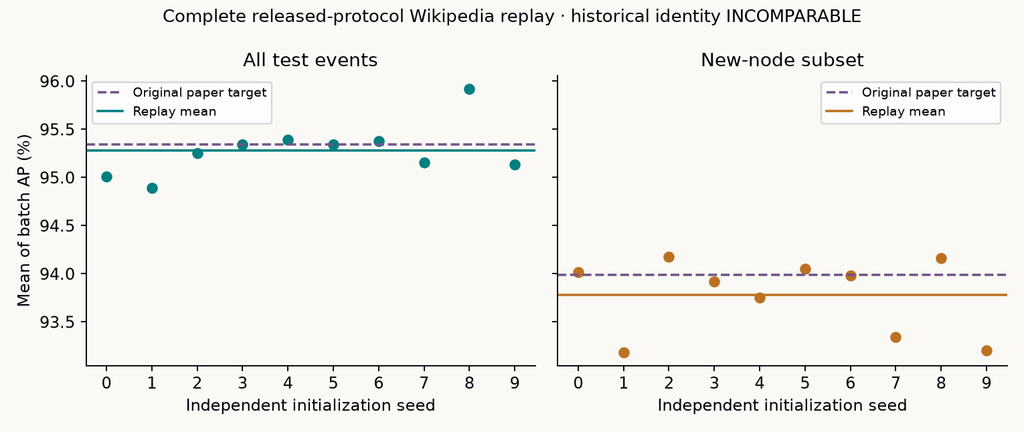

Per-seed AP in the complete released-protocol replay. Dashed paper targets refer to the original reported populations; numerical proximity does not resolve the protocol differences.

**Read the result plot.** Each point is one initialization under the same declared release protocol. Compare the spread to the published target without treating initialization seeds as new datasets.

**Before trusting a result, trace these choices.** We pin the raw data hash, publication-era source, preprocessing, held-node split, dimensions, initialization, sampler, BCE objective, Adam settings, checkpoint rule, seeds and metric aggregation. We preserve the released neighbor and batch omissions and the shifted checkpoint index. The undefined `args.new_node` reference is omitted because it is inert and otherwise prevents the original entrypoint from starting. Read the complete [protocol and deviation ledger](https://avistian.github.io/relational/labs/l103-reproduction.md), [source manifest](https://avistian.github.io/relational/labs/_sources_l103.json), and [data audit](https://avistian.github.io/relational/labs/_audit_l103_results.json).

> **Scope check.** Source output/gradient equality is evidence about implementation. A ten-run mean is evidence about this executed protocol. Neither establishes every experiment in the paper, original runtime identity, or superiority on other datasets. Reddit, private industrial data, downstream node classification and the full baseline/ablation suite are not reproduced here.

## 7 · Compare TGAT and TGN under one declared protocol

A direct subtraction from lesson 102's author scores would mix model and experiment differences. Instead, this lesson runs six fresh fits: TGAT and TGN at three seeds each.

**Held fixed:** 2000 training, 400 validation and 400 test interactions; the same retained event graph; the same per-seed destination negatives; one layer; latest ten strict-past neighbors; batch 200; Adam 10⁻⁴; dropout 0.1; three epochs. Each arm selects its own best validation pooled AP. Test AP is computed on the full retained prediction vector, not averaged over batches.

**Varied:** TGAT recomputes temporal embeddings; TGN maintains persistent node memory. Their attention widths, parameter counts and empty-neighborhood handling also differ. This experiment compares two implementations under a shared protocol; it does not isolate the causal effect of memory alone. TGN's selected checkpoint restores memory, clocks and pending messages together.

Before revealing the table, predict whether three short runs can establish general architectural superiority. Name a factor that might reverse the ordering at full training scale.

| Seed | TGAT test AP | TGN test AP | TGN − TGAT |
| --- | --- | --- | --- |
| 0 | 80.359% | 82.704% | +2.345 pp |
| 1 | 83.015% | 83.477% | +0.462 pp |
| 2 | 83.369% | 87.704% | +4.335 pp |

**TGAT: 82.248% ± 1.645 pp sample SD**; **TGN: 84.628% ± 2.692 pp sample SD**. These are author-reference measurements, separate from your fresh notebook run. **MEASURED course experiment; paper comparison INCOMPARABLE.** [Complete traces](https://avistian.github.io/relational/labs/_comparison_l103_results.json).

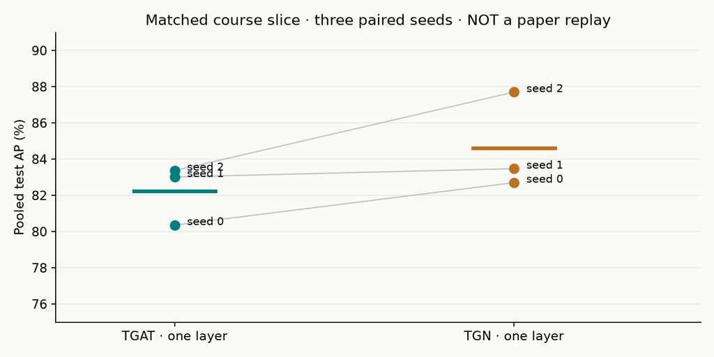

Each line pairs a common seed and negative schedule across models. Horizontal strokes are means; three seeds on one event slice do not establish benchmark superiority.

The seed standard deviation describes variation on this one fixed event slice. Seeds are not independent datasets. We do not perform a cross-dataset rank test or claim a benchmark winner from this comparison.

## 8 · Lab: your code must control the trained model

Open the [student notebook](https://avistian.github.io/relational/labs/0103-tgat.ipynb), [prepared notebook view](https://avistian.github.io/relational/labs/html/0103-tgat.html), or [executed teacher solution](https://avistian.github.io/relational/labs/solutions/0103-tgat.ipynb). The notebook includes this explanation, portable figures, and the complete readable TGAT and TGN implementations used in its comparison.

1. **TODO — functional encoding:** implement broadcasting of elapsed times against learned frequency and phase vectors. CHECK verifies values, shape, and gradients.
2. **TODO — temporal attention:** implement scaled query/key compatibility and the declared padding behavior. CHECK includes an all-padding counterexample.
3. **TODO — strict history:** implement the lower-bound cutoff used in the corrected comparison. CHECK covers empty histories, tied timestamps and boundaries.

The subsequent training loop calls these functions. They are not disconnected exercises. The default notebook executes a small fresh matched comparison; its numbers are your kernel's results. Author evidence is labeled separately. A post-EXIT switch runs the complete release replay with the same visible TGAT implementation. The smoke, closer and paper presets denote different execution budgets, not different strengths of reproduction claims.

## 9 · Written defense and the next lesson

Submit your three functions and training output with these five answers:

- Trace a two-layer request with root time 8, first interaction time 5 and child interaction time 6. Explain exactly where the last interaction is rejected.
- Derive the paired sine/cosine inner-product identity. Explain why it does not establish the same property for arbitrary learned cosine-only features.
- Explain how changing elapsed time changes both attention weights and weighted content, and why the result need not be monotone in age.
- Contrast TGAT's event history and sampling RNG with TGN's memory, clocks and pending messages. What must a reproducible checkpoint preserve?
- State the strongest claim supported by the selected replay and the common-protocol comparison. Identify one source defect and one historical detail still not established.

**Teach back:** explain the five points above without copying the lesson, then ask the tutor to challenge your reasoning.

Ask the tutor about any unclear step, or paste your written defense for strict feedback. Return tomorrow and redraw the recursive cutoff path from memory. In a week, explain the encoder-to-score path without reading the diagram.

**Forward connection:** lesson 104 audits temporal leakage. This lesson gives it two concrete failure modes: a child representation queried at the root's later time, and a current interaction inserted before its own prediction. Later, time tokens in relational models will reuse the representation idea; they will still need a valid information boundary.

**Primary reading:** [Xu et al., Inductive Representation Learning on Temporal Graphs, §§3–4 and Appendix A.5](https://arxiv.org/html/2002.07962v1). Read §3.1 for the functional encoding and §3.2 for recursive attention, then audit the [released implementation](https://github.com/StatsDLMathsRecomSys/Inductive-representation-learning-on-temporal-graphs/tree/9293d10d1943c4bd4a186337cf38ba98e4c8bb99). Keep the [TGAT reference card](https://avistian.github.io/relational/reference/tgat-time-attention.html) for review.

**Carry this forward.** Audit which records actually entered that representation. [Continue to Lesson 104](https://avistian.github.io/relational/lessons/0104-information-leakage-in-time.html).

## Visible TGAT implementation

Read each named chunk. The replay preserves documented source quirks; the corrected comparison uses the strict temporal-boundary function you implement. The three TODOs directly affect the model trained below.

### PROVIDED · Imports and frozen identities

```python
import copy
import hashlib
import json
import math
import random
import time
import urllib.request
from pathlib import Path
import numpy as np
import pandas as pd
import torch
from torch import nn
from sklearn.metrics import average_precision_score, roc_auc_score
SOURCE_COMMIT='9293d10d1943c4bd4a186337cf38ba98e4c8bb99'
DATA_URL='https://snap.stanford.edu/jodie/wikipedia.csv'
DATA_SHA256='a6b73e09c0d1e5b9db11e7e7aa416f2e87838a745273e0446a79952cf4cfae09'
PAPER_AP={'all':95.34,'new':93.99}
CLOSE_TOLERANCE_PP=0.5
```

### PROVIDED · Task 1: functional time encoding, release parameterization

```python
def encode_time(elapsed, frequency, phase):
    """Map elapsed [B,N] and trainable [D] frequencies/phases to [B,N,D]."""
    return torch.cos(elapsed.unsqueeze(-1)*frequency+phase)
```

### CHECK — do not edit

```python
x=torch.tensor([[0.,2.]],requires_grad=True);frequency=torch.tensor([1.,.5],requires_grad=True);phase=torch.zeros(2,requires_grad=True)
y=encode_time(x,frequency,phase)
assert y.shape==(1,2,2), 'Broadcast to B × N × D'
assert torch.allclose(y[0,0],torch.ones(2)), 'Zero elapsed and zero phase must give cosine(0)'
assert torch.allclose(y[0,1],torch.cos(torch.tensor([2.,1.]))), 'Frequency multiplies elapsed time'
y.sum().backward();assert frequency.grad is not None and phase.grad is not None and frequency.grad.abs().sum()>0 and phase.grad.abs().sum()>0 and x.grad.abs().sum()>0, 'Keep the gradient path'
print('PASS: values, dimensions and gradients')
```

```
PASS: values, dimensions and gradients
```

### PROVIDED · Task 2: scaled masked attention

```python
def attention_weights(query, keys, padding):
    """[H*B,1,D] x [H*B,N,D] -> [H*B,1,N]; True means padding.
    Preserve the release's finite -1e10 mask, including uniform all-padding rows.
    """
    scores=torch.bmm(query,keys.transpose(1,2))/math.sqrt(query.shape[-1])
    return torch.softmax(scores.masked_fill(padding,-1e10),dim=-1)
```

### CHECK — do not edit

```python
q=torch.tensor([[[1.,0.]]],requires_grad=True);keys=torch.tensor([[[1.,0.],[0.,1.],[9.,9.]]],requires_grad=True);mask=torch.tensor([[[False,False,True]]])
a=attention_weights(q,keys,mask)
assert a.shape==(1,1,3) and a[0,0,2]==0, 'Mask padding before normalizing'
assert abs(a[0,0,0].item()-1/(1+math.exp(-1/math.sqrt(2))))<1e-6, 'Scale by sqrt(head width)'
assert torch.allclose(a.sum(-1),torch.ones(1,1)), 'Normalize over neighbors'
assert torch.allclose(attention_weights(q,keys,torch.ones_like(mask)),torch.full((1,1,3),1/3)), 'Preserve the declared finite-mask release convention'
a[0,0,0].backward();assert q.grad is not None and q.grad.abs().sum()>0 and keys.grad is not None and keys.grad.abs().sum()>0, 'Preserve query/key gradients'
assert not keys.grad[0,2].any(), 'Padded keys must receive zero gradient'
print('PASS: scaling, padding, query/key gradients and all-padding counterexample')
```

```
PASS: scaling, padding, query/key gradients and all-padding counterexample
```

### PROVIDED · Task 3: strict-past temporal boundary for the corrected comparison

```python
def strict_prefix(sorted_times, cutoff):
    """Number of events strictly before cutoff; exclude every equal timestamp."""
    return int(np.searchsorted(sorted_times,cutoff,side='left'))
```

### CHECK — do not edit

```python
for times in [[],[1],[1,1,2,4],[0,3,9]]:
    for cutoff in [-1,0,1,2,3,4,10]:
        expected=sum(t<cutoff for t in times)
        assert strict_prefix(np.array(times),cutoff)==expected, 'Use strictly before; exclude all tied times'
print('PASS: empty, ties, exact cutoffs and end boundaries')
```

```
PASS: empty, ties, exact cutoffs and end boundaries
```

### PROVIDED · Temporal neighborhoods: declared release behavior or corrected boundary

```python
class NeighborFinder:
    def __init__(self, events, n_nodes, release=True, uniform=True):
        rows=[[] for _ in range(n_nodes)]
        for u,v,t,e in zip(events['u'],events['v'],events['t'],events['e']):
            rows[int(u)].append((int(v),int(e),float(t)))
            rows[int(v)].append((int(u),int(e),float(t)))
        # Release sorts by edge ID. For this stream, IDs are chronological.
        self.rows=[np.asarray(sorted(r,key=lambda z:z[1] if release else z[2]),dtype=np.float64).reshape(-1,3) for r in rows]
        self.release,self.uniform=release,uniform
    def find_before(self,node,cutoff):
        a=self.rows[int(node)];ts=a[:,2]
        if not self.release:
            end=strict_prefix(ts,cutoff)
        elif not len(a):
            end=0
        else:
            # Exact released binary-search/slice convention, including its omitted item.
            left,right=0,len(a)-1
            while left+1<right:
                middle=(left+right)//2
                if ts[middle]<cutoff:left=middle
                else:right=middle
            end=right if ts[right]<cutoff else left
        return a[:end]
    def get_temporal_neighbor(self,nodes,cutoffs,num_neighbors=20):
        ids=np.zeros((len(nodes),num_neighbors),dtype=np.int32)
        edges=np.zeros_like(ids);times=np.zeros(ids.shape,dtype=np.float32)
        for i,(node,cutoff) in enumerate(zip(nodes,cutoffs)):
            history=self.find_before(node,cutoff)
            if not len(history):continue
            if self.uniform:
                chosen=history[np.random.randint(0,len(history),num_neighbors)]
                ids[i],edges[i],times[i]=chosen[:,0],chosen[:,1],chosen[:,2]
                order=times[i].argsort();ids[i],edges[i],times[i]=ids[i,order],edges[i,order],times[i,order]
            else:
                chosen=history[:num_neighbors] if self.release else history[-num_neighbors:]
                ids[i,-len(chosen):],edges[i,-len(chosen):],times[i,-len(chosen):]=chosen[:,0],chosen[:,1],chosen[:,2]
        return ids,edges,times
```

### PROVIDED · Trainable encoder and feed-forward merge

```python
class TimeEncoder(nn.Module):
    def __init__(self,dim):
        super().__init__()
        self.basis_freq=nn.Parameter(torch.tensor(1/10**np.linspace(0,9,dim),dtype=torch.float32))
        self.phase=nn.Parameter(torch.zeros(dim))
    def forward(self,elapsed):return encode_time(elapsed,self.basis_freq,self.phase)

class Merge(nn.Module):
    def __init__(self,left,right,hidden,out):
        super().__init__();self.fc1=nn.Linear(left+right,hidden);self.fc2=nn.Linear(hidden,out)
        nn.init.xavier_normal_(self.fc1.weight);nn.init.xavier_normal_(self.fc2.weight)
    def forward(self,left,right):return self.fc2(torch.relu(self.fc1(torch.cat([left,right],dim=-1))))
```

### PROVIDED · Multi-head attention: projection, aggregation, residual and normalization

```python
class MultiHead(nn.Module):
    def __init__(self,width,heads,dropout):
        super().__init__();assert width%heads==0
        self.heads,self.head_dim=heads,width//heads
        self.w_qs=nn.Linear(width,width,bias=False);self.w_ks=nn.Linear(width,width,bias=False);self.w_vs=nn.Linear(width,width,bias=False)
        for layer in [self.w_qs,self.w_ks,self.w_vs]:nn.init.normal_(layer.weight,std=np.sqrt(2/(width+self.head_dim)))
        self.layer_norm=nn.LayerNorm(width);self.fc=nn.Linear(width,width);nn.init.xavier_normal_(self.fc.weight)
        self.dropout=nn.Dropout(dropout)
    def forward(self,q,k,mask):
        batch=q.shape[0]
        def split(x,projection):
            return projection(x).view(batch,-1,self.heads,self.head_dim).permute(2,0,1,3).contiguous().view(self.heads*batch,-1,self.head_dim)
        query,keys,values=split(q,self.w_qs),split(k,self.w_ks),split(k,self.w_vs)
        weights=self.dropout(attention_weights(query,keys,mask.repeat(self.heads,1,1)))
        mixed=torch.bmm(weights,values).view(self.heads,batch,1,self.head_dim).permute(1,2,0,3).contiguous().view(batch,1,-1)
        return self.layer_norm(q+self.dropout(self.fc(mixed)))

class TemporalAttention(nn.Module):
    def __init__(self,dim,heads,dropout):
        super().__init__();self.merger=Merge(3*dim,dim,dim,dim);self.multi_head_target=MultiHead(3*dim,heads,dropout)
    def forward(self,source,zero_time,neighbors,elapsed,edge,padding):
        q=torch.cat([source[:,None,:],torch.zeros_like(source[:,None,:]),zero_time],dim=-1)
        kv=torch.cat([neighbors,edge,elapsed],dim=-1)
        context=self.multi_head_target(q,kv,padding[:,None,:]).squeeze(1)
        return self.merger(context,source)
```

### PROVIDED · Complete recursive TGAT encoder and shared positive/negative decoder

```python
class TGAT(nn.Module):
    def __init__(self,finder,node_features,edge_features,layers=2,heads=2,dropout=.1):
        super().__init__();self.num_layers=layers;self.ngh_finder=finder
        # Preserve release registration and initialization order for parity checks.
        self.n_feat_th=nn.Parameter(torch.as_tensor(node_features,dtype=torch.float32))
        self.e_feat_th=nn.Parameter(torch.as_tensor(edge_features,dtype=torch.float32))
        self.edge_raw_embed=nn.Embedding.from_pretrained(self.e_feat_th,padding_idx=0,freeze=True)
        self.node_raw_embed=nn.Embedding.from_pretrained(self.n_feat_th,padding_idx=0,freeze=True)
        d=node_features.shape[1];assert edge_features.shape[1]==d
        self.merge_layer=Merge(d,d,d,d) # unused released module, retained for RNG/state identity
        self.attn_model_list=nn.ModuleList([TemporalAttention(d,heads,dropout) for _ in range(layers)])
        self.time_encoder=TimeEncoder(d);self.affinity_score=Merge(d,d,d,1)
    def tem_conv(self,nodes,cutoffs,layer,num_neighbors=20):
        device=self.n_feat_th.device
        raw=self.node_raw_embed(torch.as_tensor(nodes,dtype=torch.long,device=device))
        if layer==0:return raw
        source=self.tem_conv(nodes,cutoffs,layer-1,num_neighbors)
        nbr,eid,when=self.ngh_finder.get_temporal_neighbor(nodes,cutoffs,num_neighbors)
        child=self.tem_conv(nbr.ravel(),when.ravel(),layer-1,num_neighbors).reshape(len(nodes),num_neighbors,-1)
        elapsed=torch.as_tensor(cutoffs[:,None]-when,dtype=torch.float32,device=device)
        time_features=self.time_encoder(elapsed)
        zero_time=self.time_encoder(torch.zeros((len(nodes),1),device=device))
        edge=self.edge_raw_embed(torch.as_tensor(eid,dtype=torch.long,device=device))
        padding=torch.as_tensor(nbr==0,device=device)
        return self.attn_model_list[layer-1](source,zero_time,child,time_features,edge,padding)
    def contrast(self,u,v,negative,t,num_neighbors=20):
        src=self.tem_conv(u,t,self.num_layers,num_neighbors)
        dst=self.tem_conv(v,t,self.num_layers,num_neighbors)
        neg=self.tem_conv(negative,t,self.num_layers,num_neighbors)
        return self.affinity_score(src,dst).flatten().sigmoid(),self.affinity_score(src,neg).flatten().sigmoid()
```

### PROVIDED · Hash-checked raw Wikipedia preprocessing and frozen temporal split

```python
def load_wikipedia(directory):
    directory = Path(directory); directory.mkdir(parents=True, exist_ok=True)
    path = directory/'wikipedia.csv'
    if not path.exists():
        urllib.request.urlretrieve(DATA_URL, path)
    sha = hashlib.file_digest(path.open('rb'), 'sha256').hexdigest()
    assert sha == DATA_SHA256, f'Dataset checksum mismatch: {sha}'
    cache = directory/'processed.npz'
    if cache.exists():
        z = np.load(cache)
        # The raw identity alone cannot authenticate an arbitrary processed cache.
        if str(z['raw_sha']) != sha:
            raise ValueError('Processed cache belongs to other raw bytes')
        u,v,t,x = (z[k] for k in ['u','v','t','x'])
    else:
        # Header has four columns, rows additionally have 172 edge features.
        a = np.loadtxt(path, delimiter=',', skiprows=1)
        u = a[:, 0].astype(np.int64)+1
        v = a[:, 1].astype(np.int64)+int(u.max())+1
        t,x = a[:, 2], a[:, 4:].astype(np.float32)
        np.savez(cache, u=u,v=v,t=t,x=x,raw_sha=sha)
    assert len(u)==157474 and x.shape==(157474,172)
    assert np.all(np.diff(t)>=0) and len(set(u)|set(v))==9227
    edges = np.vstack([np.zeros((1,172),np.float32),x])
    nodes = np.zeros((int(max(u.max(),v.max()))+1,172),np.float32)
    full = {'u':u,'v':v,'t':t,'e':np.arange(1,len(u)+1)}
    val_time,test_time = np.quantile(t,[.70,.85])
    candidates = set(u[t>val_time]) | set(v[t>val_time])
    # Python 3.9 random.sample(set, k) internally converted to tuple. Preserve that order.
    held = set(random.Random(2020).sample(tuple(candidates),int(.1*(len(nodes)-1))))
    train_mask = (t<=val_time)&~np.isin(u,list(held))&~np.isin(v,list(held))
    seen = set(u[train_mask])|set(v[train_mask]); unseen=(set(u)|set(v))-seen
    novel = np.isin(u,list(unseen))|np.isin(v,list(unseen))
    masks={'train':train_mask,'val':(t>val_time)&(t<=test_time),'test':t>test_time}
    masks['new_val']=masks['val']&novel; masks['new_test']=masks['test']&novel
    data={name:{k:a[mask] for k,a in full.items()} for name,mask in masks.items()}
    data['full']=full
    audit={'raw_sha256':sha,'cutoffs':[float(val_time),float(test_time)],
           'counts':{k:len(d['u']) for k,d in data.items()},'held_nodes':sorted(int(i) for i in held),
           'split_sha256':{k:hashlib.sha256(d['e'].tobytes()).hexdigest() for k,d in data.items()}}
    return nodes,edges,data,audit
```

### PROVIDED · Release negative sampling, batch boundaries and metrics

```python
class NegativeSampler:
    def __init__(self,events):self.u=np.unique(events['u']);self.v=np.unique(events['v'])
    def sample(self,n):
        np.random.randint(0,len(self.u),n) # release consumes an unused source draw
        return self.v[np.random.randint(0,len(self.v),n)]

def event_batches(events,size,release=True):
    n=len(events['u'])
    for start in range(0,n,size):
        end=min(n-1 if release else n,start+size)
        if end<=start:continue # avoid empty-batch crash; original Wikipedia has no empty tail
        yield {k:x[start:end] for k,x in events.items()}

@torch.no_grad()
def evaluate(model,events,sampler,neighbors=20,batch_size=30,release=True):
    model.eval();rows=[];saved=[]
    for b in event_batches(events,batch_size,release):
        neg=sampler.sample(len(b['u']));p,n=model.contrast(b['u'],b['v'],neg,b['t'],neighbors)
        p,n=p.cpu().numpy(),n.cpu().numpy();scores=np.r_[p,n];truth=np.r_[np.ones(len(p)),np.zeros(len(n))]
        rows.append([average_precision_score(truth,scores),roc_auc_score(truth,scores),np.mean((scores>.5)==truth)])
        saved.append({'e':b['e'],'negative':neg,'p':p,'n':n,'batch':np.full(len(p),len(rows)-1)})
    return dict(zip(['ap','auc','accuracy'],np.mean(rows,axis=0).tolist())),saved

def compact_weights(model):
    return {k:v.detach().cpu().clone() for k,v in model.state_dict().items() if k not in ['n_feat_th','e_feat_th','edge_raw_embed.weight','node_raw_embed.weight']}
```

### PROVIDED · Complete released-experiment training and checkpoint selection

```python
def run_training(nodes,edges,data,seed=0,epochs=50,output=None,device='cpu',neighbors=20,layers=2,release=True):
    """Complete modern release replay. Historical exact seed identity is unavailable."""
    torch.manual_seed(seed);np.random.seed(seed)
    train=data['train'];train_finder=NeighborFinder(train,len(nodes),release);full_finder=NeighborFinder(data['full'],len(nodes),release)
    model=TGAT(train_finder,nodes,edges,layers=layers).to(device)
    optimizer=torch.optim.Adam(model.parameters(),lr=.0001)
    train_sampler=NegativeSampler(train);val_sampler=NegativeSampler(data['full'])
    idx=np.arange(len(train['u']));np.random.shuffle(idx) # retained even though release never uses idx
    output=Path(output or f'l103-paper/seed-{seed}');output.mkdir(parents=True,exist_ok=True)
    trace=[];best=None;best_epoch=0;rounds=0;stopped=False
    for epoch in range(epochs):
        begin=time.perf_counter();np.random.shuffle(idx);model.ngh_finder=train_finder;model.train();losses=[]
        for b in event_batches(train,200,release):
            optimizer.zero_grad();p,n=model.contrast(b['u'],b['v'],train_sampler.sample(len(b['u'])),b['t'],neighbors)
            loss=nn.functional.binary_cross_entropy(p,torch.ones_like(p))+nn.functional.binary_cross_entropy(n,torch.zeros_like(n))
            loss.backward();optimizer.step();losses.append(float(loss.detach()))
        model.ngh_finder=full_finder
        val,_=evaluate(model,data['val'],val_sampler,neighbors,release=release)
        new_val,_=evaluate(model,data['new_val'],val_sampler,neighbors,release=release)
        if best is None:best=val['ap']
        elif (val['ap']-best)/abs(best)>.001:
            best=val['ap'];rounds=0;best_epoch=epoch+1 if release else epoch
        else:rounds+=1
        row={'epoch':epoch,'loss':float(np.mean(losses)),'val_ap':val['ap'],'new_val_ap':new_val['ap'],'seconds':time.perf_counter()-begin}
        trace.append(row);print(json.dumps({'seed':seed,**row}),flush=True)
        (output/'progress.json').write_text(json.dumps(trace,indent=2))
        if rounds>=3:
            model.load_state_dict(torch.load(output/f'epoch-{best_epoch}.pt',map_location=device,weights_only=True),strict=False)
            stopped=True;break
        torch.save(compact_weights(model),output/f'epoch-{epoch}.pt')
    selected=best_epoch if stopped else len(trace)-1
    # Save the RNG state immediately before evaluation for an exact source replay.
    np_state=np.random.get_state();torch_state=torch.get_rng_state()
    torch.save({'weights':compact_weights(model),'numpy_state':np_state,'torch_state':torch_state},output/'selected.pt')
    test,pred=evaluate(model,data['test'],NegativeSampler(data['full']),neighbors,release=release)
    new_test,new_pred=evaluate(model,data['new_test'],NegativeSampler(data['new_test']),neighbors,release=release)
    np.savez_compressed(output/'predictions.npz',**{f'{lane}_{k}':np.concatenate([x[k] for x in records]) for lane,records in [('all',pred),('new',new_pred)] for k in records[0]})
    result={'seed':seed,'epochs_completed':len(trace),'selected_epoch':selected,'early_stopped':stopped,'test':test,'new_test':new_test,'trace':trace,'release_quirks':release,'neighbors':neighbors,'layers':layers,'train_events':len(train['u'])-(1 if release else 0),'test_events':sum(len(x['e']) for x in pred),'new_test_events':sum(len(x['e']) for x in new_pred)}
    (output/'result.json').write_text(json.dumps(result,indent=2));return result
```

## Visible TGN baseline from lesson 102

The full one-layer model and its released trainer are included below for independent reading. The shared comparison uses `TGN` with the common trainer that follows. Auxiliary names receive a `TGN_` prefix to keep both implementations live in this notebook. The notebook routes TGN's strict cutoff through your live `strict_prefix` task too, replacing its equivalent NumPy lower-bound call. These are complete state updates, not a packaged baseline.

### PROVIDED · TGN · Imports and immutable experiment identities

```python
import copy
import hashlib
import json
import math
import random
import time
import urllib.request
from pathlib import Path

import numpy as np
import pandas as pd
import torch
from torch import nn
from sklearn.metrics import average_precision_score, roc_auc_score

TGN_SOURCE_COMMIT = 'e38cdf85998c6ca077167610dc4e769a688efa95'
DATA_URL = 'https://snap.stanford.edu/jodie/wikipedia.csv'
DATA_SHA256 = 'a6b73e09c0d1e5b9db11e7e7aa416f2e87838a745273e0446a79952cf4cfae09'
TGN_PAPER_AP = {'all': 98.46, 'new': 97.81}
TGN_CLOSE_TOLERANCE_PP = 0.5
```

### PROVIDED · TGN · Task 1: last-message aggregation

```python
def last_message_indices(node_ids):
    """Last occurrence per node, returned in sorted-node order (chronological input)."""
    last = {}
    for i, node in enumerate(node_ids):
        last[int(node)] = i
    return np.array([last[node] for node in sorted(last)], dtype=np.int64)
```

### PROVIDED · TGN · Task 2: raw interaction messages

```python
def raw_messages(own, other, edge, elapsed, time_encoder):
    """Eq. 1 identity message: [own state, other state, event features, elapsed encoding]."""
    return torch.cat([own, other, edge, time_encoder(elapsed[:, None]).squeeze(1)], dim=1)
```

### PROVIDED · TGN · Task 3: differentiable memory update

```python
def update_state(memory, last_update, nodes, messages, timestamps, gru):
    """New candidate state; do not mutate the pre-event state that messages refer to."""
    state, clock = memory.detach().clone(), last_update.detach().clone()
    if len(nodes):
        assert bool((clock[nodes] <= timestamps).all()), 'Memory would travel backward in time'
        state[nodes] = gru(messages, state[nodes])
        clock[nodes] = timestamps
    return state, clock
```

### PROVIDED · TGN · Strict temporal adjacency and release negative sampling

```python
def temporal_neighbors(u, v, t, edge_ids, n_nodes):
    adjacency = [[] for _ in range(n_nodes)]
    for a, b, when, eid in zip(u, v, t, edge_ids):
        adjacency[int(a)].append((int(b), int(eid), float(when)))
        adjacency[int(b)].append((int(a), int(eid), float(when)))
    adjacency = [np.asarray(sorted(rows, key=lambda x: x[2]), dtype=np.float64).reshape(-1, 3)
                 for rows in adjacency]
    def find(nodes, cutoffs, count):
        neighbors = np.zeros((len(nodes), count), dtype=np.int64)
        ids = np.zeros_like(neighbors)
        times = np.zeros(neighbors.shape, dtype=np.float32)
        for row, (node, cutoff) in enumerate(zip(nodes, cutoffs)):
            history = adjacency[int(node)]
            end = strict_prefix(history[:, 2], cutoff)
            chosen = history[max(0, end-count):end]
            if len(chosen):
                neighbors[row, -len(chosen):] = chosen[:, 0]
                ids[row, -len(chosen):] = chosen[:, 1]
                times[row, -len(chosen):] = chosen[:, 2]
        return neighbors, ids, times
    return find


class TGN_NegativeSampler:
    """Uniform destinations; consume the unused source draw to preserve release RNG order."""
    def __init__(self, events, seed=None):
        self.sources = np.unique(events['u'])
        self.destinations = np.unique(events['v'])
        self.seed = seed
        self.reset()
    def reset(self):
        self.rng = np.random if self.seed is None else np.random.RandomState(self.seed)
    def sample(self, size):
        self.rng.randint(0, len(self.sources), size)
        return self.destinations[self.rng.randint(0, len(self.destinations), size)]
```

### PROVIDED · TGN · Time encoder and merge blocks

```python
class TGN_TimeEncoder(nn.Module):
    def __init__(self, dim):
        super().__init__()
        self.w = nn.Linear(1, dim)
        self.w.weight = nn.Parameter(torch.tensor(1 / 10 ** np.linspace(0, 9, dim), dtype=torch.float32)[:, None])
        self.w.bias = nn.Parameter(torch.zeros(dim))
    def forward(self, elapsed):
        return torch.cos(self.w(elapsed.unsqueeze(-1)))


class TGN_Merge(nn.Module):
    def __init__(self, left, right, hidden, out):
        super().__init__()
        self.fc1, self.fc2 = nn.Linear(left+right, hidden), nn.Linear(hidden, out)
        nn.init.xavier_normal_(self.fc1.weight)
        nn.init.xavier_normal_(self.fc2.weight)
    def forward(self, left, right):
        return self.fc2(torch.relu(self.fc1(torch.cat([left, right], dim=-1))))
```

### PROVIDED · TGN · Complete one-layer TGN-attn encoder and decoder

```python
class TGN(nn.Module):
    def __init__(self, node_features, edge_features, dropout=0.1, neighbors=10):
        super().__init__()
        d = node_features.shape[1]
        self.dim, self.neighbors = d, neighbors
        self.register_buffer('node_features', torch.as_tensor(node_features, dtype=torch.float32))
        self.register_buffer('edge_features', torch.as_tensor(edge_features, dtype=torch.float32))
        self.time_encoder = TGN_TimeEncoder(d)
        self.gru = nn.GRUCell(3*d+edge_features.shape[1], d)
        self.merge = TGN_Merge(2*d, d, d, d)
        self.attention = nn.MultiheadAttention(2*d, 2, kdim=2*d+edge_features.shape[1],
                                              vdim=2*d+edge_features.shape[1], dropout=dropout)
        self.decoder = TGN_Merge(d, d, d, 1)
        self.register_buffer('memory', torch.zeros_like(self.node_features))
        self.register_buffer('last_update', torch.zeros(len(node_features)))
        self.pending = {}
        self.finder = None
    def reset_state(self):
        self.memory.zero_(); self.last_update.zero_(); self.pending = {}
    def detach_state(self):
        self.memory = self.memory.detach()
        self.pending = {k: (m.detach(), t.detach()) for k, (m, t) in self.pending.items()}
    def snapshot(self):
        return (self.memory.detach().clone(), self.last_update.clone(),
                {k: (m.detach().clone(), t.clone()) for k, (m, t) in self.pending.items()})
    def restore(self, state):
        self.memory, self.last_update, self.pending = copy.deepcopy(state)
    def candidate_state(self):
        nodes = sorted(self.pending)
        messages = torch.stack([self.pending[k][0] for k in nodes]) if nodes else None
        times = torch.stack([self.pending[k][1] for k in nodes]) if nodes else None
        return update_state(self.memory, self.last_update, nodes, messages, times, self.gru)
    def embed(self, nodes, timestamps, state):
        device = self.memory.device
        node_ids = torch.as_tensor(nodes, dtype=torch.long, device=device)
        own = state[node_ids] + self.node_features[node_ids]
        neighbors, edges, times = self.finder(nodes, timestamps, self.neighbors)
        neighbors = torch.as_tensor(neighbors, dtype=torch.long, device=device)
        edges = torch.as_tensor(edges, dtype=torch.long, device=device)
        elapsed = torch.as_tensor(timestamps[:, None] - times, dtype=torch.float32, device=device)
        query = torch.cat([own[:, None], self.time_encoder(torch.zeros((len(nodes), 1), device=device))], dim=-1)
        key = torch.cat([state[neighbors]+self.node_features[neighbors], self.edge_features[edges],
                         self.time_encoder(elapsed)], dim=-1)
        mask = neighbors == 0
        empty = mask.all(dim=1)
        mask[empty, 0] = False  # MHA softmax must not receive an all-masked row.
        output, _ = self.attention(query.transpose(0, 1), key.transpose(0, 1), key.transpose(0, 1),
                                   key_padding_mask=mask)
        output = output.squeeze(0).masked_fill(empty[:, None], 0)
        return self.merge(output, own)
    def probabilities(self, u, v, negative, timestamps, edge_ids):
        """Score first using old messages; queue current positive events only afterward."""
        state, clock = self.candidate_state()
        embeddings = self.embed(np.concatenate([u, v, negative]), np.tile(timestamps, 3), state)
        src, dst, neg = embeddings.chunk(3)
        # Persist consumed messages only for real endpoints, exactly as release TGN does.
        positives = np.unique(np.concatenate([u, v]))
        with torch.no_grad():
            self.memory[positives] = state[positives]
            self.last_update[positives] = clock[positives]
        for node in positives:
            self.pending.pop(int(node), None)
        device = self.memory.device
        when = torch.as_tensor(timestamps, dtype=torch.float32, device=device)
        # Source and destination messages both use the same pre-current-event state.
        for own, other in [(u, v), (v, u)]:
            messages = raw_messages(self.memory[own], self.memory[other], self.edge_features[edge_ids],
                                    when-self.last_update[own], self.time_encoder)
            for idx in last_message_indices(own):
                self.pending[int(own[idx])] = (messages[idx], when[idx])
        scores = self.decoder(torch.cat([src, src]), torch.cat([dst, neg])).flatten().sigmoid()
        return scores.chunk(2)
```

### PROVIDED · TGN · Complete data preprocessing and frozen release split

```python
def TGN_load_wikipedia(directory):
    directory = Path(directory); directory.mkdir(parents=True, exist_ok=True)
    path = directory/'wikipedia.csv'
    if not path.exists():
        urllib.request.urlretrieve(DATA_URL, path)
    sha = hashlib.file_digest(path.open('rb'), 'sha256').hexdigest()
    assert sha == DATA_SHA256, f'Dataset checksum mismatch: {sha}'
    cache = directory/'processed.npz'
    if cache.exists():
        z = np.load(cache)
        # The raw identity alone cannot authenticate an arbitrary processed cache.
        if str(z['raw_sha']) != sha:
            raise ValueError('Processed cache belongs to other raw bytes')
        u,v,t,x = (z[k] for k in ['u','v','t','x'])
    else:
        # Header has four columns, rows additionally have 172 edge features.
        a = np.loadtxt(path, delimiter=',', skiprows=1)
        u = a[:, 0].astype(np.int64)+1
        v = a[:, 1].astype(np.int64)+int(u.max())+1
        t,x = a[:, 2], a[:, 4:].astype(np.float32)
        np.savez(cache, u=u,v=v,t=t,x=x,raw_sha=sha)
    assert len(u)==157474 and x.shape==(157474,172)
    assert np.all(np.diff(t)>=0) and len(set(u)|set(v))==9227
    edges = np.vstack([np.zeros((1,172),np.float32),x])
    nodes = np.zeros((int(max(u.max(),v.max()))+1,172),np.float32)
    full = {'u':u,'v':v,'t':t,'e':np.arange(1,len(u)+1)}
    val_time,test_time = np.quantile(t,[.70,.85])
    candidates = set(u[t>val_time]) | set(v[t>val_time])
    # Python 3.9 random.sample(set, k) internally converted to tuple. Preserve that order.
    held = set(random.Random(2020).sample(tuple(candidates),int(.1*(len(nodes)-1))))
    train_mask = (t<=val_time)&~np.isin(u,list(held))&~np.isin(v,list(held))
    seen = set(u[train_mask])|set(v[train_mask]); unseen=(set(u)|set(v))-seen
    novel = np.isin(u,list(unseen))|np.isin(v,list(unseen))
    masks={'train':train_mask,'val':(t>val_time)&(t<=test_time),'test':t>test_time}
    masks['new_val']=masks['val']&novel; masks['new_test']=masks['test']&novel
    data={name:{k:a[mask] for k,a in full.items()} for name,mask in masks.items()}
    data['full']=full
    audit={'raw_sha256':sha,'cutoffs':[float(val_time),float(test_time)],
           'counts':{k:len(d['u']) for k,d in data.items()},'held_nodes':sorted(int(i) for i in held),
           'split_sha256':{k:hashlib.sha256(d['e'].tobytes()).hexdigest() for k,d in data.items()}}
    return nodes,edges,data,audit
```

### PROVIDED · TGN · Full chronological train/evaluation loops and named-target runner

```python
def TGN_batches(events, size=200):
    for start in range(0,len(events['u']),size):
        yield {k:v[start:start+size] for k,v in events.items()}


def TGN_evaluate(model, events, sampler, batch_size=200):
    model.eval(); sampler.reset(); aps=[]; aucs=[]; saved=[]
    with torch.no_grad():
        for b in TGN_batches(events,batch_size):
            neg=sampler.sample(len(b['u']))
            positive,negative=model.probabilities(b['u'],b['v'],neg,b['t'],b['e'])
            p=np.concatenate([positive.cpu().numpy(),negative.cpu().numpy()])
            y=np.concatenate([np.ones(len(positive)),np.zeros(len(negative))])
            aps.append(float(average_precision_score(y,p))); aucs.append(float(roc_auc_score(y,p)))
            saved.append({'edges':b['e'],'negative':neg,'positive':positive.cpu().numpy(),'negative_score':negative.cpu().numpy()})
    return {'ap':float(np.mean(aps)),'auc':float(np.mean(aucs)),'batch_ap':aps,'batch_auc':aucs},saved


def TGN_run_training(nodes,edges,data,seed=0,epochs=50,patience=5,batch_size=200,output=None,device='cpu'):
    """Fixed-seed modern port. Release checkpoint/pending-message behavior is preserved."""
    torch.manual_seed(seed); np.random.seed(seed)
    model=TGN(nodes,edges).to(device)
    full_finder=temporal_neighbors(**{'u':data['full']['u'],'v':data['full']['v'],'t':data['full']['t'],
                                    'edge_ids':data['full']['e'],'n_nodes':len(nodes)})
    train=data['train']
    train_finder=temporal_neighbors(train['u'],train['v'],train['t'],train['e'],len(nodes))
    train_sampler=TGN_NegativeSampler(train)
    val_sampler=TGN_NegativeSampler(data['full'],0)
    test_sampler=TGN_NegativeSampler(data['full'],2)
    new_sampler=TGN_NegativeSampler(data['new_test'],3)
    optimizer=torch.optim.Adam(model.parameters(),lr=1e-4)
    trace=[]; best=-float('inf'); rounds=0; best_epoch=0; best_weights=None; stop=False
    for epoch in range(epochs):
        start=time.perf_counter();model.reset_state();model.finder=train_finder;model.train();losses=[]
        for b in TGN_batches(train,batch_size):
            optimizer.zero_grad()
            p,n=model.probabilities(b['u'],b['v'],train_sampler.sample(len(b['u'])),b['t'],b['e'])
            loss=nn.functional.binary_cross_entropy(p,torch.ones_like(p))+nn.functional.binary_cross_entropy(n,torch.zeros_like(n))
            loss.backward();optimizer.step();model.detach_state();losses.append(float(loss.detach()))
        model.finder=full_finder
        train_state=model.snapshot()
        val,_=TGN_evaluate(model,data['val'],val_sampler,batch_size)
        val_state=model.snapshot();model.restore(train_state)
        # The released trainer intentionally passes the full-node validation sampler here.
        new_val,_=TGN_evaluate(model,data['new_val'],val_sampler,batch_size)
        model.restore(val_state)
        improved=best_weights is None or (val['ap']-best)/abs(best)>1e-10
        if improved:
            best=val['ap'];best_epoch=epoch;rounds=0
            best_weights={k:v.detach().clone() for k,v in model.state_dict().items()
                          if k not in ['node_features','edge_features']}
        else: rounds+=1
        row={'epoch':epoch,'loss':float(np.mean(losses)),'val_ap':val['ap'],'new_val_ap':new_val['ap'],
             'seconds':time.perf_counter()-start}
        trace.append(row);print(json.dumps({'seed':seed,**row}),flush=True)
        if output:
            Path(output).mkdir(parents=True,exist_ok=True)
            (Path(output)/f'seed-{seed}-progress.json').write_text(json.dumps(trace,indent=2))
        if rounds>=patience:
            # Release does not serialize pending messages in state_dict. Keep stopping-epoch
            # pending messages when restoring its best weights and persistent memory.
            model.load_state_dict(best_weights,strict=False);stop=True;break
    # Release uses the final epoch if the maximum is reached without early stopping.
    selected=best_epoch if stop else len(trace)-1
    val_state=model.snapshot()
    test,predictions=TGN_evaluate(model,data['test'],test_sampler,batch_size)
    model.restore(val_state)
    new_test,new_predictions=TGN_evaluate(model,data['new_test'],new_sampler,batch_size)
    model.restore(val_state)
    result={'seed':seed,'epochs_completed':len(trace),'selected_epoch':selected,'early_stopped':stop,
            'test':test,'new_test':new_test,'trace':trace,
            'seed_protocol':'Independent explicit seed per run; release originally seeds once before ten runs',
            'checkpoint_policy':'release: best state_dict on early stop; pending messages from stopping epoch'}
    if output:
        out=Path(output)
        torch.save({'weights':{k:v for k,v in model.state_dict().items() if k not in ['node_features','edge_features']},
                    'temporal_state':model.snapshot(),'result':result},out/f'seed-{seed}.pt')
        arrays={f'{lane}_{k}':np.concatenate([b[k] for b in values])
                for lane,values in [('all',predictions),('new',new_predictions)] for k in values[0]}
        np.savez_compressed(out/f'seed-{seed}-predictions.npz',**arrays)
        (out/f'seed-{seed}.json').write_text(json.dumps(result,indent=2))
    return result
```

### PROVIDED · Shared event budget and fixed negative schedule

```python
import copy
import json
import time
from pathlib import Path
import numpy as np
import torch
from torch import nn
from sklearn.metrics import average_precision_score,roc_auc_score
# The notebook builder removes these imports after inlining both model definitions.

def common_data(data,train_count=2000,eval_count=400):
    out={name:{k:v[:train_count if name=='train' else eval_count] for k,v in data[name].items()} for name in ['train','val','test']}
    full={k:np.concatenate([out[name][k] for name in ['train','val','test']]) for k in out['train']}
    out['full']=full
    return out

def fixed_negatives(data,seed):
    result={}
    for i,name in enumerate(['train','val','test']):
        pool=np.unique(data['train' if name=='train' else 'full']['v'])
        result[name]=np.random.RandomState(seed+1000*(i+1)).choice(pool,len(data[name]['u']))
    return result
```

### PROVIDED · Shared trainer: three epochs, validation-only selection, pooled held-out AP

```python
def run_comparison(nodes,edges,data,seed=0,epochs=3,output=None,device='cpu'):
    negatives=fixed_negatives(data,seed);records=[]
    for arm in ['TGAT','TGN']:
        torch.manual_seed(seed);np.random.seed(seed);begin=time.perf_counter()
        if arm=='TGAT':
            train_finder=NeighborFinder(data['train'],len(nodes),release=False,uniform=False)
            full_finder=NeighborFinder(data['full'],len(nodes),release=False,uniform=False)
            model=TGAT(train_finder,nodes,edges,layers=1).to(device)
        else:
            def make(events):return temporal_neighbors(events['u'],events['v'],events['t'],events['e'],len(nodes))
            train_finder,full_finder=make(data['train']),make(data['full'])
            model=TGN(nodes,edges).to(device)
        optimizer=torch.optim.Adam(model.parameters(),lr=1e-4)
        def run(name,training):
            events=data[name];ps=[];ns=[];losses=[];model.train(training)
            for start in range(0,len(events['u']),200):
                b={k:x[start:start+200] for k,x in events.items()};negative=negatives[name][start:start+200]
                with torch.set_grad_enabled(training):
                    if training:optimizer.zero_grad()
                    if arm=='TGAT':p,n=model.contrast(b['u'],b['v'],negative,b['t'],10)
                    else:p,n=model.probabilities(b['u'],b['v'],negative,b['t'],b['e'])
                    loss=nn.functional.binary_cross_entropy(p,torch.ones_like(p))+nn.functional.binary_cross_entropy(n,torch.zeros_like(n))
                    if training:loss.backward();optimizer.step()
                    if arm=='TGN':model.detach_state()
                ps.extend(p.detach().cpu().tolist());ns.extend(n.detach().cpu().tolist());losses.append(float(loss.detach()))
            y=np.r_[np.ones(len(ps)),np.zeros(len(ns))];scores=np.r_[ps,ns]
            return {'ap':float(average_precision_score(y,scores)),'auc':float(roc_auc_score(y,scores)),'loss':float(np.mean(losses))},np.asarray(ps),np.asarray(ns)
        best=-1;trace=[];selected=0
        for epoch in range(epochs):
            if arm=='TGAT':model.ngh_finder=train_finder
            else:model.finder=train_finder;model.reset_state()
            train,_,_=run('train',True)
            if arm=='TGAT':model.ngh_finder=full_finder
            else:model.finder=full_finder
            with torch.no_grad():val,_,_=run('val',False)
            trace.append({'epoch':epoch,'train':train,'val':val})
            if val['ap']>best:
                best=val['ap'];selected=epoch
                weights={k:v.detach().clone() for k,v in model.state_dict().items() if k not in ['node_features','edge_features','n_feat_th','e_feat_th','node_raw_embed.weight','edge_raw_embed.weight']}
                state=copy.deepcopy(model.snapshot()) if arm=='TGN' else None
        model.load_state_dict(weights,strict=False)
        if arm=='TGN':model.restore(state)
        with torch.no_grad():test,p,n=run('test',False)
        row={'arm':arm,'seed':seed,'selected_epoch':selected,'test':test,'trace':trace,'seconds':time.perf_counter()-begin,'trainable_used_note':'TGAT retains unused release parameters; parameter counts are not a matched budget'}
        if output:
            out=Path(output);out.mkdir(parents=True,exist_ok=True)
            np.savez_compressed(out/f'{arm}-{seed}-predictions.npz',positive=p,negative_score=n,negative=negatives['test'],edges=data['test']['e'])
            torch.save({'weights':weights,'state':state},out/f'{arm}-{seed}.pt')
            (out/f'{arm}-{seed}.json').write_text(json.dumps(row,indent=2))
        print(json.dumps({k:v for k,v in row.items() if k!='trace'}),flush=True);records.append(row)
    return records
```

## Predict, then execute your live comparison

Predict whether one epoch can establish which architecture is generally better. It cannot: this is a small implementation experiment. Both models receive the same retained graph and negative destinations. Your corrected sampler, encoder and attention function are on the TGAT training path.

```python
torch.set_num_threads(1)
DATA_DIRECTORY=Path('l103-cache')
node_features,edge_features,full_data,data_audit=load_wikipedia(DATA_DIRECTORY)
display(pd.DataFrame([data_audit['counts']]))
teaching=common_data(full_data,train_count=600,eval_count=120)
fresh=run_comparison(node_features,edge_features,teaching,seed=0,epochs=1,output=Path('l103-teaching'))
display(pd.DataFrame([{'model':r['arm'],'test_AP':r['test']['ap'],'selected_epoch':r['selected_epoch']} for r in fresh]))
print('MEASURED fresh teaching run; historical comparison INCOMPARABLE')
```

|  | train | val | test | new_val | new_test | full |
| --- | --- | --- | --- | --- | --- | --- |
| 0 | 81029 | 23621 | 23621 | 12016 | 11715 | 157474 |

```
{"arm": "TGAT", "seed": 0, "selected_epoch": 0, "test": {"ap": 0.7995417563707219, "auc": 0.7932638888888889, "loss": 1.232061505317688}, "seconds": 2.8452899100011564, "trainable_used_note": "TGAT retains unused release parameters; parameter counts are not a matched budget"}
```

```
{"arm": "TGN", "seed": 0, "selected_epoch": 0, "test": {"ap": 0.7700598530547849, "auc": 0.8096527777777778, "loss": 1.2840574979782104}, "seconds": 1.0491890220000641, "trainable_used_note": "TGAT retains unused release parameters; parameter counts are not a matched budget"}
```

|  | model | test_AP | selected_epoch |
| --- | --- | --- | --- |
| 0 | TGAT | 0.799542 | 0 |
| 1 | TGN | 0.770060 | 0 |

```
MEASURED fresh teaching run; historical comparison INCOMPARABLE
```

## EXIT TICKET

Submit your three functions, the fresh result table and the five-part written defense in section 9. Explain one source defect without treating a corrected rerun as the same experiment. Prepared solution execution does not establish mastery. **PENDING_WRITTEN_DEFENSE**.

## NEXT STEP — complete released Wikipedia replay

The same visible TGAT model and trainer run all ten independent full-data seeds below. No architecture downscale: two layers, two heads, 20 sampled neighbors, 172 feature width, up to 50 epochs with released early stopping. This can take hours; the unattended Modal command is in `labs/l103-reproduction.md`. The switch defaults OFF. Historical protocol remains INCOMPARABLE; full-paper parity NOT_ESTABLISHED even if the chosen AP cells are numerically close.

```python
RUN_PAPER_REPRO=False
if RUN_PAPER_REPRO:
    device='cuda' if torch.cuda.is_available() else 'cpu'
    paper_records=[run_training(node_features,edge_features,full_data,seed=seed,epochs=50,output=Path('l103-paper')/f'seed-{seed}',device=device) for seed in range(10)]
    display(pd.DataFrame([{'seed':r['seed'],'all_AP':r['test']['ap'],'new_AP':r['new_test']['ap']} for r in paper_records]))
else:
    print('Full replay NOT_RUN in this kernel. See separately labeled author evidence.')
```

```
Full replay NOT_RUN in this kernel. See separately labeled author evidence.
```